# Risk Factor Analysis

## Outcome Variable

**Outcome Variable:** whz

## Predictor Variables

**Intervention Variable:** single

**Adjustment Set:**

- arm
- W_mage
- meducyrs
- feducyrs
- W_mhtcm
- W_mwtkg
- W_mbmi
- delta_W_mage
- delta_meducyrs
- delta_feducyrs
- delta_W_mhtcm
- delta_W_mwtkg
- delta_W_mbmi

## Stratifying Variables

The analysis was stratified on these variable(s):

- agecat
- studyid
- country

## Data Summary

| agecat | studyid | country | single | n_cell | n | outcome_variable |
| --- | --- | --- | --- | --- | --- | --- |
| Birth | COHORTS | GUATEMALA | 0 | 654 | 691 | whz |
| Birth | COHORTS | GUATEMALA | 1 | 37 | 691 | whz |
| Birth | COHORTS | INDIA | 0 | 4456 | 4463 | whz |
| Birth | COHORTS | INDIA | 1 | 7 | 4463 | whz |
| Birth | COHORTS | PHILIPPINES | 0 | 2789 | 2860 | whz |
| Birth | COHORTS | PHILIPPINES | 1 | 71 | 2860 | whz |
| Birth | JiVitA-4 | BANGLADESH | 0 | 2388 | 2393 | whz |
| Birth | JiVitA-4 | BANGLADESH | 1 | 5 | 2393 | whz |
| Birth | MAL-ED | BANGLADESH | 0 | 215 | 215 | whz |
| Birth | MAL-ED | BANGLADESH | 1 | 0 | 215 | whz |
| Birth | MAL-ED | BRAZIL | 0 | 54 | 62 | whz |
| Birth | MAL-ED | BRAZIL | 1 | 8 | 62 | whz |
| Birth | MAL-ED | INDIA | 0 | 45 | 45 | whz |
| Birth | MAL-ED | INDIA | 1 | 0 | 45 | whz |
| Birth | MAL-ED | NEPAL | 0 | 26 | 26 | whz |
| Birth | MAL-ED | NEPAL | 1 | 0 | 26 | whz |
| Birth | MAL-ED | PERU | 0 | 205 | 228 | whz |
| Birth | MAL-ED | PERU | 1 | 23 | 228 | whz |
| Birth | MAL-ED | SOUTH AFRICA | 0 | 63 | 120 | whz |
| Birth | MAL-ED | SOUTH AFRICA | 1 | 57 | 120 | whz |
| Birth | MAL-ED | TANZANIA, UNITED REPUBLIC OF | 0 | 112 | 115 | whz |
| Birth | MAL-ED | TANZANIA, UNITED REPUBLIC OF | 1 | 3 | 115 | whz |
| Birth | PROBIT | BELARUS | 0 | 13277 | 13817 | whz |
| Birth | PROBIT | BELARUS | 1 | 540 | 13817 | whz |
| Birth | ZVITAMBO | ZIMBABWE | 0 | 12065 | 12864 | whz |
| Birth | ZVITAMBO | ZIMBABWE | 1 | 799 | 12864 | whz |
| 6 months | COHORTS | GUATEMALA | 0 | 827 | 894 | whz |
| 6 months | COHORTS | GUATEMALA | 1 | 67 | 894 | whz |
| 6 months | COHORTS | INDIA | 0 | 4955 | 4964 | whz |
| 6 months | COHORTS | INDIA | 1 | 9 | 4964 | whz |

[output cut: 54 more lines]

The following strata were considered:

- agecat: 24 months, studyid: COHORTS, country: GUATEMALA
- agecat: 24 months, studyid: COHORTS, country: INDIA
- agecat: 24 months, studyid: COHORTS, country: PHILIPPINES
- agecat: 24 months, studyid: JiVitA-4, country: BANGLADESH
- agecat: 24 months, studyid: MAL-ED, country: BANGLADESH
- agecat: 24 months, studyid: MAL-ED, country: BRAZIL
- agecat: 24 months, studyid: MAL-ED, country: INDIA
- agecat: 24 months, studyid: MAL-ED, country: NEPAL
- agecat: 24 months, studyid: MAL-ED, country: PERU
- agecat: 24 months, studyid: MAL-ED, country: SOUTH AFRICA
- agecat: 24 months, studyid: MAL-ED, country: TANZANIA, UNITED REPUBLIC OF
- agecat: 24 months, studyid: PROBIT, country: BELARUS
- agecat: 24 months, studyid: TanzaniaChild2, country: TANZANIA, UNITED REPUBLIC OF
- agecat: 24 months, studyid: ZVITAMBO, country: ZIMBABWE
- agecat: 6 months, studyid: COHORTS, country: GUATEMALA
- agecat: 6 months, studyid: COHORTS, country: INDIA
- agecat: 6 months, studyid: COHORTS, country: PHILIPPINES
- agecat: 6 months, studyid: Guatemala BSC, country: GUATEMALA
- agecat: 6 months, studyid: JiVitA-4, country: BANGLADESH
- agecat: 6 months, studyid: MAL-ED, country: BANGLADESH
- agecat: 6 months, studyid: MAL-ED, country: BRAZIL
- agecat: 6 months, studyid: MAL-ED, country: INDIA
- agecat: 6 months, studyid: MAL-ED, country: NEPAL
- agecat: 6 months, studyid: MAL-ED, country: PERU
- agecat: 6 months, studyid: MAL-ED, country: SOUTH AFRICA
- agecat: 6 months, studyid: MAL-ED, country: TANZANIA, UNITED REPUBLIC OF
- agecat: 6 months, studyid: PROBIT, country: BELARUS
- agecat: 6 months, studyid: TanzaniaChild2, country: TANZANIA, UNITED REPUBLIC OF
- agecat: 6 months, studyid: ZVITAMBO, country: ZIMBABWE
- agecat: Birth, studyid: COHORTS, country: GUATEMALA
- agecat: Birth, studyid: COHORTS, country: INDIA
- agecat: Birth, studyid: COHORTS, country: PHILIPPINES
- agecat: Birth, studyid: JiVitA-4, country: BANGLADESH
- agecat: Birth, studyid: MAL-ED, country: BANGLADESH
- agecat: Birth, studyid: MAL-ED, country: BRAZIL
- agecat: Birth, studyid: MAL-ED, country: INDIA
- agecat: Birth, studyid: MAL-ED, country: NEPAL
- agecat: Birth, studyid: MAL-ED, country: PERU
- agecat: Birth, studyid: MAL-ED, country: SOUTH AFRICA
- agecat: Birth, studyid: MAL-ED, country: TANZANIA, UNITED REPUBLIC OF
- agecat: Birth, studyid: PROBIT, country: BELARUS
- agecat: Birth, studyid: ZVITAMBO, country: ZIMBABWE

### Dropped Strata

Some strata were dropped due to rare outcomes:

- agecat: Birth, studyid: MAL-ED, country: BANGLADESH
- agecat: Birth, studyid: MAL-ED, country: INDIA
- agecat: Birth, studyid: MAL-ED, country: NEPAL
- agecat: Birth, studyid: MAL-ED, country: TANZANIA, UNITED REPUBLIC OF
- agecat: 6 months, studyid: MAL-ED, country: BANGLADESH
- agecat: 6 months, studyid: MAL-ED, country: INDIA
- agecat: 6 months, studyid: MAL-ED, country: NEPAL
- agecat: 24 months, studyid: MAL-ED, country: BANGLADESH
- agecat: 24 months, studyid: MAL-ED, country: INDIA
- agecat: 24 months, studyid: MAL-ED, country: NEPAL
- agecat: 24 months, studyid: TanzaniaChild2, country: TANZANIA, UNITED REPUBLIC OF

## Methods Detail

We’re interested in the causal parameters $E[Y_a]$ for all values of $a \in \mathcal{A}$. These parameters represent the mean outcome if, possibly contrary to fact, we intervened to set all units to have $A=a$. Under the randomization and positivity assumptions, these are identified by the statistical parameters $\psi_a=E_W[E_{Y|A,W}(Y|A=a,W)]$. In addition, we’re interested in the mean of $Y$, $E[Y]$ under no intervention (the observed mean). We will estimate these parameters by using SuperLearner to fit the relevant likelihood factors – $E_{Y|A,W}(Y|A=a,W)$ and $p(A=a|W)$, and then updating our likelihood fit using a joint TMLE.

For unadjusted analyses ($W=\{\}$), initial likelihoods were estimated using Lrnr_glm to estimate the simple $E(Y|A)$ and Lrnr_mean to estimate $p(A)$. For adjusted analyses, a small library containing Lrnr_glmnet, Lrnr_xgboost, and Lrnr_mean was used.

Having estimated these parameters, we will then use the delta method to estimate relative risks and attributable risks relative to a prespecified baseline level of $A$.

# Results Detail

## Results Plots

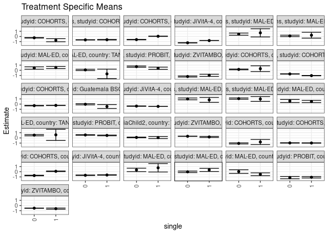

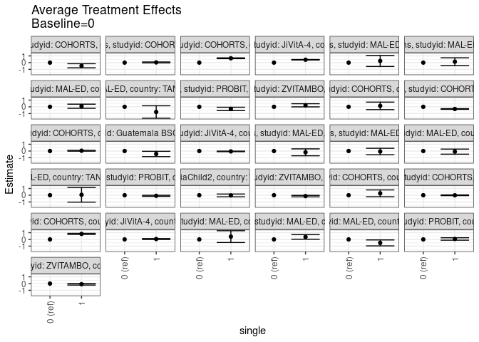

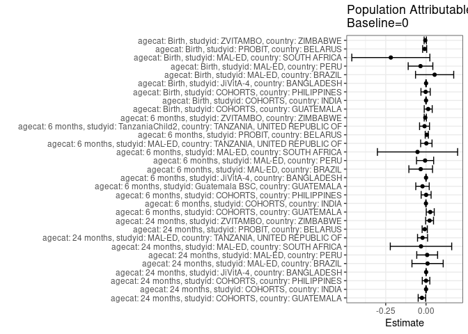

## Results Table

### Parameter: TSM

| agecat | studyid | country | intervention_level | baseline_level | estimate | ci_lower | ci_upper |
| --- | --- | --- | --- | --- | --- | --- | --- |
| Birth | COHORTS | GUATEMALA | 0 | NA | -1.0688037 | -1.1786517 | -0.9589558 |
| Birth | COHORTS | GUATEMALA | 1 | NA | -0.7907070 | -1.2840391 | -0.2973748 |
| Birth | COHORTS | INDIA | 0 | NA | -0.9764901 | -1.0121932 | -0.9407871 |
| Birth | COHORTS | INDIA | 1 | NA | -0.9871429 | -1.0249916 | -0.9492941 |
| Birth | COHORTS | PHILIPPINES | 0 | NA | -0.7350747 | -0.7913720 | -0.6787774 |
| Birth | COHORTS | PHILIPPINES | 1 | NA | 0.0798816 | 0.0183332 | 0.1414299 |
| Birth | JiVitA-4 | BANGLADESH | 0 | NA | -0.6889322 | -0.7427226 | -0.6351417 |
| Birth | JiVitA-4 | BANGLADESH | 1 | NA | -0.6340000 | -0.6780019 | -0.5899981 |
| Birth | MAL-ED | BRAZIL | 0 | NA | 0.3496296 | 0.0129664 | 0.6862928 |
| Birth | MAL-ED | BRAZIL | 1 | NA | 0.7625000 | -0.0474852 | 1.5724852 |
| Birth | MAL-ED | PERU | 0 | NA | -0.0178084 | -0.1657450 | 0.1301283 |
| Birth | MAL-ED | PERU | 1 | NA | 0.3494964 | 0.0433519 | 0.6556408 |
| Birth | MAL-ED | SOUTH AFRICA | 0 | NA | 0.0257302 | -0.3173607 | 0.3688211 |
| Birth | MAL-ED | SOUTH AFRICA | 1 | NA | -0.4948233 | -0.7696708 | -0.2199759 |
| Birth | PROBIT | BELARUS | 0 | NA | -1.1407689 | -1.3546851 | -0.9268528 |
| Birth | PROBIT | BELARUS | 1 | NA | -1.0774912 | -1.2197589 | -0.9352236 |
| Birth | ZVITAMBO | ZIMBABWE | 0 | NA | -0.5101820 | -0.5369840 | -0.4833801 |
| Birth | ZVITAMBO | ZIMBABWE | 1 | NA | -0.6023715 | -0.7247444 | -0.4799985 |
| 6 months | COHORTS | GUATEMALA | 0 | NA | 0.1658524 | 0.0898500 | 0.2418547 |
| 6 months | COHORTS | GUATEMALA | 1 | NA | 0.3091653 | -0.2450606 | 0.8633912 |
| 6 months | COHORTS | INDIA | 0 | NA | -0.7098951 | -0.7430287 | -0.6767615 |
| 6 months | COHORTS | INDIA | 1 | NA | -1.0322222 | -1.0700926 | -0.9943519 |
| 6 months | COHORTS | PHILIPPINES | 0 | NA | -0.2943063 | -0.3473606 | -0.2412520 |
| 6 months | COHORTS | PHILIPPINES | 1 | NA | -0.2524060 | -0.2827316 | -0.2220805 |
| 6 months | Guatemala BSC | GUATEMALA | 0 | NA | -0.0349642 | -0.1563694 | 0.0864410 |
| 6 months | Guatemala BSC | GUATEMALA | 1 | NA | -0.4707119 | -0.8448936 | -0.0965301 |
| 6 months | JiVitA-4 | BANGLADESH | 0 | NA | -0.3903686 | -0.4286532 | -0.3520840 |
| 6 months | JiVitA-4 | BANGLADESH | 1 | NA | -0.4493750 | -0.4619543 | -0.4367957 |
| 6 months | MAL-ED | BRAZIL | 0 | NA | 1.0050975 | 0.8292907 | 1.1809044 |
| 6 months | MAL-ED | BRAZIL | 1 | NA | 0.8120464 | 0.3323311 | 1.2917618 |
| 6 months | MAL-ED | PERU | 0 | NA | 1.0587596 | 0.9314899 | 1.1860292 |
| 6 months | MAL-ED | PERU | 1 | NA | 0.9879170 | 0.5271944 | 1.4486396 |
| 6 months | MAL-ED | SOUTH AFRICA | 0 | NA | 0.5950219 | 0.2871205 | 0.9029232 |
| 6 months | MAL-ED | SOUTH AFRICA | 1 | NA | 0.5031699 | 0.2816767 | 0.7246630 |
| 6 months | MAL-ED | TANZANIA, UNITED REPUBLIC OF | 0 | NA | 0.5343375 | 0.4035792 | 0.6650959 |
| 6 months | MAL-ED | TANZANIA, UNITED REPUBLIC OF | 1 | NA | 0.5925000 | -0.4882365 | 1.6732365 |
| 6 months | PROBIT | BELARUS | 0 | NA | 0.5694790 | 0.5105589 | 0.6283990 |
| 6 months | PROBIT | BELARUS | 1 | NA | 0.4794319 | 0.4096286 | 0.5492352 |
| 6 months | TanzaniaChild2 | TANZANIA, UNITED REPUBLIC OF | 0 | NA | 0.0891063 | 0.0268989 | 0.1513137 |
| 6 months | TanzaniaChild2 | TANZANIA, UNITED REPUBLIC OF | 1 | NA | 0.0599339 | -0.1388780 | 0.2587458 |
| 6 months | ZVITAMBO | ZIMBABWE | 0 | NA | 0.3154650 | 0.2888149 | 0.3421151 |
| 6 months | ZVITAMBO | ZIMBABWE | 1 | NA | 0.1808933 | 0.0724515 | 0.2893352 |
| 24 months | COHORTS | GUATEMALA | 0 | NA | -0.2542127 | -0.3123219 | -0.1961035 |
| 24 months | COHORTS | GUATEMALA | 1 | NA | -0.7231489 | -1.0220130 | -0.4242848 |
| 24 months | COHORTS | INDIA | 0 | NA | -0.6594835 | -0.6934635 | -0.6255034 |
| 24 months | COHORTS | INDIA | 1 | NA | -0.6300000 | -0.6887577 | -0.5712423 |
| 24 months | COHORTS | PHILIPPINES | 0 | NA | -0.6100915 | -0.6546609 | -0.5655220 |
| 24 months | COHORTS | PHILIPPINES | 1 | NA | 0.0361729 | 0.0014572 | 0.0708886 |
| 24 months | JiVitA-4 | BANGLADESH | 0 | NA | -1.2245351 | -1.2573027 | -1.1917674 |
| 24 months | JiVitA-4 | BANGLADESH | 1 | NA | -0.7950000 | -0.8090439 | -0.7809561 |
| 24 months | MAL-ED | BRAZIL | 0 | NA | 0.4530989 | 0.2387659 | 0.6674319 |
| 24 months | MAL-ED | BRAZIL | 1 | NA | 0.7004285 | -0.0873278 | 1.4881849 |
| 24 months | MAL-ED | PERU | 0 | NA | 0.1040833 | -0.0339372 | 0.2421038 |
| 24 months | MAL-ED | PERU | 1 | NA | 0.2428661 | -0.3207538 | 0.8064861 |
| 24 months | MAL-ED | SOUTH AFRICA | 0 | NA | 0.4402379 | 0.2084781 | 0.6719978 |
| 24 months | MAL-ED | SOUTH AFRICA | 1 | NA | 0.5277406 | 0.3274363 | 0.7280448 |
| 24 months | MAL-ED | TANZANIA, UNITED REPUBLIC OF | 0 | NA | 0.0763782 | -0.0483716 | 0.2011280 |
| 24 months | MAL-ED | TANZANIA, UNITED REPUBLIC OF | 1 | NA | -0.6933333 | -1.6135001 | 0.2268334 |
| 24 months | PROBIT | BELARUS | 0 | NA | 0.7062801 | 0.5860642 | 0.8264961 |
| 24 months | PROBIT | BELARUS | 1 | NA | 0.3933667 | 0.1727893 | 0.6139440 |
| 24 months | ZVITAMBO | ZIMBABWE | 0 | NA | -1.2017607 | -1.3093944 | -1.0941271 |
| 24 months | ZVITAMBO | ZIMBABWE | 1 | NA | -0.9745854 | -1.1835494 | -0.7656214 |

### Parameter: E(Y)

| agecat | studyid | country | intervention_level | baseline_level | estimate | ci_lower | ci_upper |
| --- | --- | --- | --- | --- | --- | --- | --- |
| Birth | COHORTS | GUATEMALA | NA | NA | -1.0552243 | -1.1617873 | -0.9486614 |
| Birth | COHORTS | INDIA | NA | NA | -0.9765068 | -1.0113301 | -0.9416835 |
| Birth | COHORTS | PHILIPPINES | NA | NA | -0.7377902 | -0.7844819 | -0.6910986 |
| Birth | JiVitA-4 | BANGLADESH | NA | NA | -0.6888174 | -0.7412201 | -0.6364147 |
| Birth | MAL-ED | BRAZIL | NA | NA | 0.4029032 | 0.0896793 | 0.7161272 |
| Birth | MAL-ED | PERU | NA | NA | -0.0520175 | -0.1725298 | 0.0684947 |
| Birth | MAL-ED | SOUTH AFRICA | NA | NA | -0.1925833 | -0.4053570 | 0.0201904 |
| Birth | PROBIT | BELARUS | NA | NA | -1.1491782 | -1.3593933 | -0.9389630 |
| Birth | ZVITAMBO | ZIMBABWE | NA | NA | -0.5148609 | -0.5407634 | -0.4889583 |
| 6 months | COHORTS | GUATEMALA | NA | NA | 0.1920134 | 0.1173734 | 0.2666534 |
| 6 months | COHORTS | INDIA | NA | NA | -0.7104795 | -0.7428008 | -0.6781581 |
| 6 months | COHORTS | PHILIPPINES | NA | NA | -0.2936948 | -0.3352840 | -0.2521057 |
| 6 months | Guatemala BSC | GUATEMALA | NA | NA | -0.0568833 | -0.1722874 | 0.0585208 |
| 6 months | JiVitA-4 | BANGLADESH | NA | NA | -0.3904664 | -0.4277855 | -0.3531473 |
| 6 months | MAL-ED | BRAZIL | NA | NA | 0.9720774 | 0.8078144 | 1.1363403 |
| 6 months | MAL-ED | PERU | NA | NA | 1.0528816 | 0.9313005 | 1.1744626 |
| 6 months | MAL-ED | SOUTH AFRICA | NA | NA | 0.5421785 | 0.3900443 | 0.6943126 |
| 6 months | MAL-ED | TANZANIA, UNITED REPUBLIC OF | NA | NA | 0.5362213 | 0.4049390 | 0.6675036 |
| 6 months | PROBIT | BELARUS | NA | NA | 0.5741099 | 0.5141290 | 0.6340908 |
| 6 months | TanzaniaChild2 | TANZANIA, UNITED REPUBLIC OF | NA | NA | 0.0797577 | 0.0268998 | 0.1326156 |
| 6 months | ZVITAMBO | ZIMBABWE | NA | NA | 0.3108992 | 0.2851818 | 0.3366167 |
| 24 months | COHORTS | GUATEMALA | NA | NA | -0.2796964 | -0.3351582 | -0.2242346 |
| 24 months | COHORTS | INDIA | NA | NA | -0.6594122 | -0.6925753 | -0.6262491 |
| 24 months | COHORTS | PHILIPPINES | NA | NA | -0.6100579 | -0.6471813 | -0.5729344 |
| 24 months | JiVitA-4 | BANGLADESH | NA | NA | -1.2239898 | -1.2559235 | -1.1920562 |
| 24 months | MAL-ED | BRAZIL | NA | NA | 0.4626233 | 0.2567495 | 0.6684971 |
| 24 months | MAL-ED | PERU | NA | NA | 0.1111982 | -0.0118399 | 0.2342362 |
| 24 months | MAL-ED | SOUTH AFRICA | NA | NA | 0.4090301 | 0.2879441 | 0.5301161 |
| 24 months | MAL-ED | TANZANIA, UNITED REPUBLIC OF | NA | NA | 0.0547975 | -0.0703378 | 0.1799328 |
| 24 months | PROBIT | BELARUS | NA | NA | 0.6981406 | 0.5843775 | 0.8119038 |
| 24 months | ZVITAMBO | ZIMBABWE | NA | NA | -1.1797222 | -1.2787189 | -1.0807256 |

### Parameter: ATE

| agecat | studyid | country | intervention_level | baseline_level | estimate | ci_lower | ci_upper |
| --- | --- | --- | --- | --- | --- | --- | --- |
| Birth | COHORTS | GUATEMALA | 0 | 0 | 0.0000000 | 0.0000000 | 0.0000000 |
| Birth | COHORTS | GUATEMALA | 1 | 0 | 0.2780968 | -0.2276036 | 0.7837972 |
| Birth | COHORTS | INDIA | 0 | 0 | 0.0000000 | 0.0000000 | 0.0000000 |
| Birth | COHORTS | INDIA | 1 | 0 | -0.0106527 | -0.0626838 | 0.0413784 |
| Birth | COHORTS | PHILIPPINES | 0 | 0 | 0.0000000 | 0.0000000 | 0.0000000 |
| Birth | COHORTS | PHILIPPINES | 1 | 0 | 0.8149563 | 0.7318025 | 0.8981101 |
| Birth | JiVitA-4 | BANGLADESH | 0 | 0 | 0.0000000 | 0.0000000 | 0.0000000 |
| Birth | JiVitA-4 | BANGLADESH | 1 | 0 | 0.0549322 | -0.0162654 | 0.1261297 |
| Birth | MAL-ED | BRAZIL | 0 | 0 | 0.0000000 | 0.0000000 | 0.0000000 |
| Birth | MAL-ED | BRAZIL | 1 | 0 | 0.4128704 | -0.4642944 | 1.2900352 |
| Birth | MAL-ED | PERU | 0 | 0 | 0.0000000 | 0.0000000 | 0.0000000 |
| Birth | MAL-ED | PERU | 1 | 0 | 0.3673047 | 0.0274691 | 0.7071403 |
| Birth | MAL-ED | SOUTH AFRICA | 0 | 0 | 0.0000000 | 0.0000000 | 0.0000000 |
| Birth | MAL-ED | SOUTH AFRICA | 1 | 0 | -0.5205535 | -0.9635091 | -0.0775980 |
| Birth | PROBIT | BELARUS | 0 | 0 | 0.0000000 | 0.0000000 | 0.0000000 |
| Birth | PROBIT | BELARUS | 1 | 0 | 0.0632777 | -0.1186081 | 0.2451635 |
| Birth | ZVITAMBO | ZIMBABWE | 0 | 0 | 0.0000000 | 0.0000000 | 0.0000000 |
| Birth | ZVITAMBO | ZIMBABWE | 1 | 0 | -0.0921894 | -0.2174088 | 0.0330299 |
| 6 months | COHORTS | GUATEMALA | 0 | 0 | 0.0000000 | 0.0000000 | 0.0000000 |
| 6 months | COHORTS | GUATEMALA | 1 | 0 | 0.1433130 | -0.4163159 | 0.7029418 |
| 6 months | COHORTS | INDIA | 0 | 0 | 0.0000000 | 0.0000000 | 0.0000000 |
| 6 months | COHORTS | INDIA | 1 | 0 | -0.3223272 | -0.3726461 | -0.2720082 |
| 6 months | COHORTS | PHILIPPINES | 0 | 0 | 0.0000000 | 0.0000000 | 0.0000000 |
| 6 months | COHORTS | PHILIPPINES | 1 | 0 | 0.0419003 | -0.0191402 | 0.1029408 |
| 6 months | Guatemala BSC | GUATEMALA | 0 | 0 | 0.0000000 | 0.0000000 | 0.0000000 |
| 6 months | Guatemala BSC | GUATEMALA | 1 | 0 | -0.4357477 | -0.8287519 | -0.0427434 |
| 6 months | JiVitA-4 | BANGLADESH | 0 | 0 | 0.0000000 | 0.0000000 | 0.0000000 |
| 6 months | JiVitA-4 | BANGLADESH | 1 | 0 | -0.0590064 | -0.0997170 | -0.0182959 |
| 6 months | MAL-ED | BRAZIL | 0 | 0 | 0.0000000 | 0.0000000 | 0.0000000 |
| 6 months | MAL-ED | BRAZIL | 1 | 0 | -0.1930511 | -0.7061292 | 0.3200269 |
| 6 months | MAL-ED | PERU | 0 | 0 | 0.0000000 | 0.0000000 | 0.0000000 |
| 6 months | MAL-ED | PERU | 1 | 0 | -0.0708425 | -0.5512899 | 0.4096048 |
| 6 months | MAL-ED | SOUTH AFRICA | 0 | 0 | 0.0000000 | 0.0000000 | 0.0000000 |
| 6 months | MAL-ED | SOUTH AFRICA | 1 | 0 | -0.0918520 | -0.4712198 | 0.2875158 |
| 6 months | MAL-ED | TANZANIA, UNITED REPUBLIC OF | 0 | 0 | 0.0000000 | 0.0000000 | 0.0000000 |
| 6 months | MAL-ED | TANZANIA, UNITED REPUBLIC OF | 1 | 0 | 0.0581625 | -1.0304555 | 1.1467805 |
| 6 months | PROBIT | BELARUS | 0 | 0 | 0.0000000 | 0.0000000 | 0.0000000 |
| 6 months | PROBIT | BELARUS | 1 | 0 | -0.0900470 | -0.1695416 | -0.0105525 |
| 6 months | TanzaniaChild2 | TANZANIA, UNITED REPUBLIC OF | 0 | 0 | 0.0000000 | 0.0000000 | 0.0000000 |
| 6 months | TanzaniaChild2 | TANZANIA, UNITED REPUBLIC OF | 1 | 0 | -0.0291724 | -0.2376963 | 0.1793514 |
| 6 months | ZVITAMBO | ZIMBABWE | 0 | 0 | 0.0000000 | 0.0000000 | 0.0000000 |
| 6 months | ZVITAMBO | ZIMBABWE | 1 | 0 | -0.1345717 | -0.2460437 | -0.0230996 |
| 24 months | COHORTS | GUATEMALA | 0 | 0 | 0.0000000 | 0.0000000 | 0.0000000 |
| 24 months | COHORTS | GUATEMALA | 1 | 0 | -0.4689362 | -0.7735796 | -0.1642927 |
| 24 months | COHORTS | INDIA | 0 | 0 | 0.0000000 | 0.0000000 | 0.0000000 |
| 24 months | COHORTS | INDIA | 1 | 0 | 0.0294835 | -0.0383923 | 0.0973592 |
| 24 months | COHORTS | PHILIPPINES | 0 | 0 | 0.0000000 | 0.0000000 | 0.0000000 |
| 24 months | COHORTS | PHILIPPINES | 1 | 0 | 0.6462644 | 0.5903086 | 0.7022202 |
| 24 months | JiVitA-4 | BANGLADESH | 0 | 0 | 0.0000000 | 0.0000000 | 0.0000000 |
| 24 months | JiVitA-4 | BANGLADESH | 1 | 0 | 0.4295351 | 0.3935671 | 0.4655030 |
| 24 months | MAL-ED | BRAZIL | 0 | 0 | 0.0000000 | 0.0000000 | 0.0000000 |
| 24 months | MAL-ED | BRAZIL | 1 | 0 | 0.2473296 | -0.5754135 | 1.0700727 |
| 24 months | MAL-ED | PERU | 0 | 0 | 0.0000000 | 0.0000000 | 0.0000000 |
| 24 months | MAL-ED | PERU | 1 | 0 | 0.1387829 | -0.4414071 | 0.7189728 |
| 24 months | MAL-ED | SOUTH AFRICA | 0 | 0 | 0.0000000 | 0.0000000 | 0.0000000 |
| 24 months | MAL-ED | SOUTH AFRICA | 1 | 0 | 0.0875026 | -0.2191466 | 0.3941518 |
| 24 months | MAL-ED | TANZANIA, UNITED REPUBLIC OF | 0 | 0 | 0.0000000 | 0.0000000 | 0.0000000 |
| 24 months | MAL-ED | TANZANIA, UNITED REPUBLIC OF | 1 | 0 | -0.7697115 | -1.6982961 | 0.1588731 |
| 24 months | PROBIT | BELARUS | 0 | 0 | 0.0000000 | 0.0000000 | 0.0000000 |
| 24 months | PROBIT | BELARUS | 1 | 0 | -0.3129135 | -0.5666258 | -0.0592012 |
| 24 months | ZVITAMBO | ZIMBABWE | 0 | 0 | 0.0000000 | 0.0000000 | 0.0000000 |
| 24 months | ZVITAMBO | ZIMBABWE | 1 | 0 | 0.2271754 | -0.0081801 | 0.4625308 |

### Parameter: PAR

| agecat | studyid | country | intervention_level | baseline_level | estimate | ci_lower | ci_upper |
| --- | --- | --- | --- | --- | --- | --- | --- |
| Birth | COHORTS | GUATEMALA | 0 | NA | 0.0135794 | -0.0111998 | 0.0383587 |
| Birth | COHORTS | INDIA | 0 | NA | -0.0000167 | -0.0013175 | 0.0012841 |
| Birth | COHORTS | PHILIPPINES | 0 | NA | -0.0027155 | -0.0314125 | 0.0259815 |
| Birth | JiVitA-4 | BANGLADESH | 0 | NA | 0.0001148 | -0.0016450 | 0.0018746 |
| Birth | MAL-ED | BRAZIL | 0 | NA | 0.0532736 | -0.0651185 | 0.1716657 |
| Birth | MAL-ED | PERU | 0 | NA | -0.0342092 | -0.1106010 | 0.0421826 |
| Birth | MAL-ED | SOUTH AFRICA | 0 | NA | -0.2183135 | -0.4603838 | 0.0237568 |
| Birth | PROBIT | BELARUS | 0 | NA | -0.0084092 | -0.0209234 | 0.0041049 |
| Birth | ZVITAMBO | ZIMBABWE | 0 | NA | -0.0046788 | -0.0117767 | 0.0024191 |
| 6 months | COHORTS | GUATEMALA | 0 | NA | 0.0261611 | 0.0014070 | 0.0509152 |
| 6 months | COHORTS | INDIA | 0 | NA | -0.0005844 | -0.0018989 | 0.0007302 |
| 6 months | COHORTS | PHILIPPINES | 0 | NA | 0.0006115 | -0.0301475 | 0.0313705 |
| 6 months | Guatemala BSC | GUATEMALA | 0 | NA | -0.0219191 | -0.0635489 | 0.0197108 |
| 6 months | JiVitA-4 | BANGLADESH | 0 | NA | -0.0000979 | -0.0011182 | 0.0009225 |
| 6 months | MAL-ED | BRAZIL | 0 | NA | -0.0330202 | -0.1063517 | 0.0403114 |
| 6 months | MAL-ED | PERU | 0 | NA | -0.0058780 | -0.0589906 | 0.0472346 |
| 6 months | MAL-ED | SOUTH AFRICA | 0 | NA | -0.0528434 | -0.3015545 | 0.1958677 |
| 6 months | MAL-ED | TANZANIA, UNITED REPUBLIC OF | 0 | NA | 0.0018838 | -0.0333985 | 0.0371662 |
| 6 months | PROBIT | BELARUS | 0 | NA | 0.0046309 | -0.0052153 | 0.0144772 |
| 6 months | TanzaniaChild2 | TANZANIA, UNITED REPUBLIC OF | 0 | NA | -0.0093486 | -0.0400927 | 0.0213956 |
| 6 months | ZVITAMBO | ZIMBABWE | 0 | NA | -0.0045658 | -0.0113996 | 0.0022681 |
| 24 months | COHORTS | GUATEMALA | 0 | NA | -0.0254836 | -0.0486729 | -0.0022944 |
| 24 months | COHORTS | INDIA | 0 | NA | 0.0000712 | -0.0016263 | 0.0017687 |
| 24 months | COHORTS | PHILIPPINES | 0 | NA | 0.0000336 | -0.0233524 | 0.0234196 |
| 24 months | JiVitA-4 | BANGLADESH | 0 | NA | 0.0005452 | -0.0004095 | 0.0014999 |
| 24 months | MAL-ED | BRAZIL | 0 | NA | 0.0095244 | -0.0872665 | 0.1063152 |
| 24 months | MAL-ED | PERU | 0 | NA | 0.0071149 | -0.0575481 | 0.0717779 |
| 24 months | MAL-ED | SOUTH AFRICA | 0 | NA | -0.0312078 | -0.2216422 | 0.1592265 |
| 24 months | MAL-ED | TANZANIA, UNITED REPUBLIC OF | 0 | NA | -0.0215807 | -0.0527095 | 0.0095481 |
| 24 months | PROBIT | BELARUS | 0 | NA | -0.0081395 | -0.0242213 | 0.0079424 |
| 24 months | ZVITAMBO | ZIMBABWE | 0 | NA | 0.0220385 | -0.0023677 | 0.0464448 |